# Лабораторная работа № 7

Операционные системы

Иванов Сергей Владимирович, НПИбд-01-23

Российский университет дружбы народов, Москва, Россия

15 марта 2024

## Цель работы

Целью данной лабораторной работы является ознакомление с файловой системой Linux, её структурой, именами и содержанием каталогов. Приобретение практических навыков по применению команд для работы с файлами и каталогами, по управлению процессами, по проверке использования диска и обслуживанию файловой системы

## Задание

1. Выполнить все примеры из лабораторной работы
2. Выполнить команды по копированию, созданию и перемещению файлов и каталогов
3. Определить опции команды chmod
4. Изменить права доступа к файлам
5. Прочитать документацию о командах mount, fsck, mkfs, kill

# Выполнение работы

## Создание файла

Создаем файл, дважды копируем его и проверяем, что все команды были выполнены корректно.

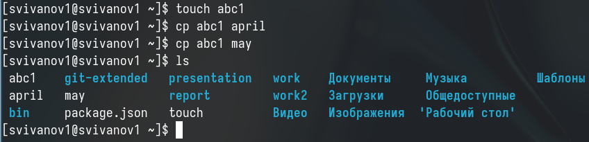

Создание файла

## Создание директории

Создаю директорию, копирую в нее два созданных файла, проверяю, что все скопировалось

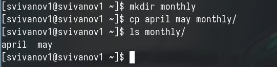

Создание директории

## Копирование файла

Копирую файл, находящийся не в текущей диреткории в файл с новым именем тоже не текущей директории

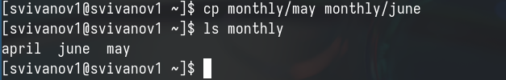

Копирование файла

## Создание директории

Создаю новую директорию. Копирую предыдущую созданную директорию со всем содержимым в каталог /tmp. Затем копирую предыдущую созданную директорию в новую созданную

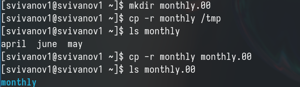

Создание директории

## Переименовывание файла

Переименовываю файл, затем перемещаю его в каталог

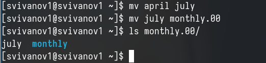

Переименовывание файла

## Создание директории

Создаю новую директорию, переименовываю файлы, перемещаю директорию в директорию reports, переименовываю эту директорию, убираю из названия 01

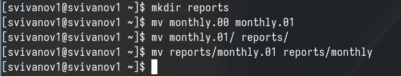

Создание директории

## Изменение прав доступа

Создаю пустой файл, проверяю права доступа у него, изменяю права доступа, добавляя пользователю возможность выполнять файл

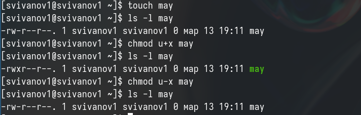

Изменение прав доступа

## Изменение прав доступа

Меняю права доступа у директории: группы и остальные пользователи не смогут ее прочетсь

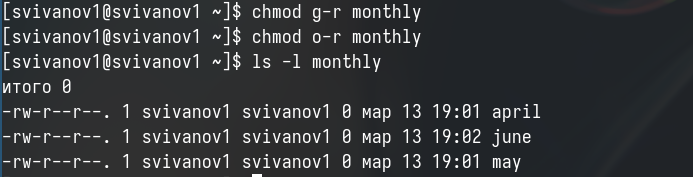

Изменение прав доступа

## Изменение прав доступа

Изменяю права доступа у директории, запрещаю группам и остальным пользователям читать. Создаю новый пустой файл, даю ему права доступа: группы могут читать и писать содержимое

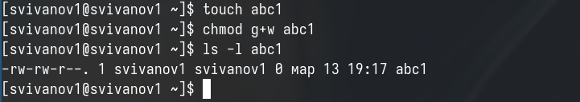

Изменение прав доступа

## Проверка файловой системы

Проверяю файловую систему

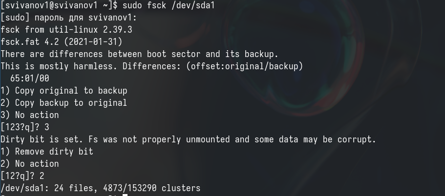

Проверка файловой системы

## Копирование файла

Копирую файл в домашний каталог с новым именем, создаю новую пустую директорию, перемещаю файл в нее, переименовываю файл

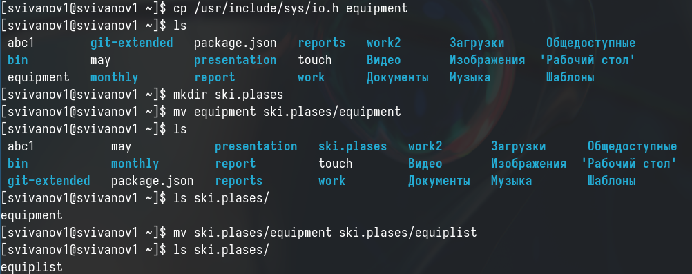

Копирование файла

## Создание файла

Создаю новый файл, копирую его в новую директорию, но сразу с новым именем. Создаю внутри этого каталога подкаталог, перемещаю файлы в подкаталог

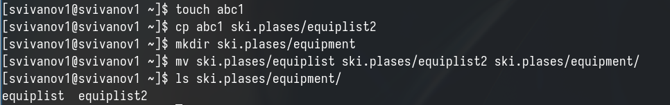

Создание файла

## Создание директории

Создаю новую директорию, перемещаю ее с новым именем в директорию, созданную в прошлый раз

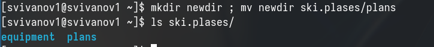

Создание директории

## Изменение прав доступа

Проверяю, какие права нужно поменять и как, чтобы у новой директории были нужные по заданию права

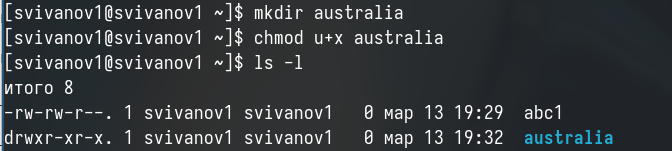

Изменение прав доступа

## Изменение прав доступа

Проверяю, какие права нужно поменять и как, чтобы у новых файлов были нужные по заданию права

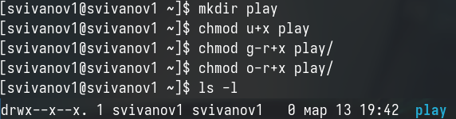

Изменение прав доступа

## Изменение прав доступа

Создаю файл, добавляю право на исполнение и убираю право на запись для владельца, затем создаю следующий файл, ему в правах доступа добавляю право на запись для группы

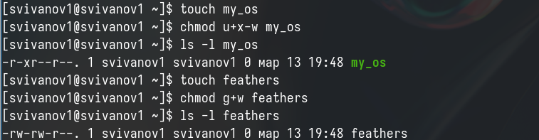

Изменение прав доступа

## Чтение файла

Читаю содержимое файла

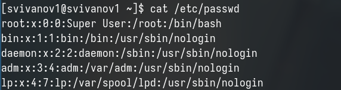

Чтение файла

## Копирование файла

Копирую файл с новым именем, перемещаю его в ранее созданную директорию, копирую ее с новым именем, копирую в нее скопированную до этого папку

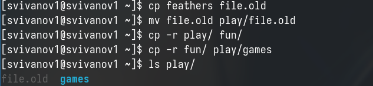

Копирование файла

## Изменение прав доступа

Убираю право на чтение у файла для создателя, поэтому не могу его прочесть, также не могу его скопировать, потому что отказано в доступе на чтение, возвращаю все права

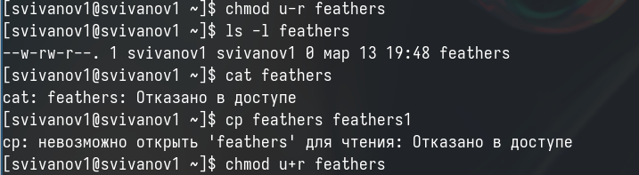

Изменение прав доступа

## Работа с правами доступа

Убираю у директории право на исполнение для пользователя, пытаюсь в нее войти - отказано в доступе, возвращаю все права

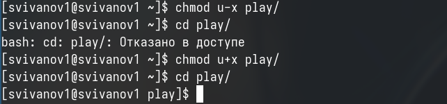

Работа с правами доступа

## Чтение документации

Я прочитал описание каждой из четырех команд с помощью man: - mount, - fsck, - mkfs, - Kill

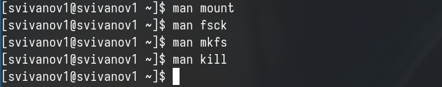

Чтение документации

# Вывод

## Вывод

При выполнении данной лабораторной работы я ознакомился с файловой системой Linux, её структурой, именами и содержанием каталогов. Приобрел практические навыки по применению команд для работы с файлами и каталогами, по управлению процессами, по проверке использования диска и обслуживанию файловой системы.

## Список литературы

https://esystem.rudn.ru/mod/page/view.php?id=1098933